# Part II: R and Probability distributions

TMA4268 Statistical Learning V2019. Module 1: INTRODUCTION TO STATISTICAL LEARNING

Mette Langaas, Martina Hall and Oyvind Bakke, Department of Mathematical Sciences, NTNU

week 2, 2019

(Latest changes: 31.12.18: first version for 2019)

Before working with this file you should have worked with the Rbeginner file: https://www.math.ntnu.no/emner/TMA4268/2019v/1Intro/Rbeginner.html

If you read the solutions version (file name ending in “sol”) the **solutions to *exercises* are included.** (For the advanced user: toggle solutions on/off in Rmd-file with variable `showsol`.)

- Version without solutions: https://www.math.ntnu.no/emner/TMA4268/2019v/1Intro/Rintermediate-sol.html
- Version with solutions: https://www.math.ntnu.no/emner/TMA4268/2019v/1Intro/Rintermediate-sol.html

(to see .Rmd or .pdf just replace in links above)

# Random variables and probability distributions

To be able to do statistics, a good understanding of random variables and probability distributions is vital.

## Background

Do you read Norwegian and want to brush up on these topics (theory, not R)? Then go to the thematic pages from TMA4240/TMA4245 Statistics and read about:

- [Random variables and probability distributions](https://wiki.math.ntnu.no/tma4245/tema/begreper/variable)
- [Important discrete distributions](https://wiki.math.ntnu.no/tma4245/tema/begreper/discrete)
- [Important continuous distributions](https://wiki.math.ntnu.no/tma4245/tema/begreper/continuous)

We will also make a function to do a $z$-test (so, just a bit of inference) and to calculate a $p$-value.

# Probability distributions in R

Tools for working with probability distributions are included in the default environment in R, and we will now look at the *binomial* (discrete) distribution and the *normal*, *chi-squared*, *t* and Fisher *F* (continuous distribution). The multivariate normal distribution will be covered in the interatice lecture of Module 2 of TMA4268 (and is also a large part of TMA4267).

For each of these distributions, there exists functions that calculates the pdf (probability density or mass function, often denoted $f$ in previous courses), the cumulative distribution function (often denoted $F$), the inverse cumulative distribution function (often denoted $F^{-1}$) and drawing random numbers form the given distribution. For the normal distribution these functions are called:

| Function | Meaning |
| --- | --- |
| dnorm | density (pdf) |
| pnorm | cumulative distribution function (cdf) |
| qnorm | inverse cumulative distribution (quantile function) |
| rnorm | draw random variable from normal distribution |

For the binomial distribution the corresponding functions are called *dbinom*, *pbinom*, *qbinom* and *rbinom*, and for the $t$-distribution we have *dt*, *pt*, *qt* and *rt*, for the $\chi^2$-distribution check out `?rchisq´ to see all functions.

Remember to check the help pages of the functions you want to use, to see what is used as input for each function. We will now look at each of these functions.

# Probability density or mass function $f(x)$

## Binomial distibution

If we study a discrete distibution – like the binomial distribution – the probability mass function gives the probability of observing $x$, $f(x) = P(X = x)$.

**Exercise:** What are the requirements that a random variable $X$ follows a binomial distribution? What are the parameters of the distribution?

**Solution:** $X$ follows a binomial distribution if its probability mass function is given by $P(X=x)={n\choose x}p^x(1-p)^{n-x}$ for $x=0$, $1$, $\ldots$, $n$, where the parameter $n$ is a positive integer and the parameter $p$ is a number between $0$ and $1$. Typically, $X$ is the number of successes in a Bernoulli process consisting of $n$ trials where the probability of success in each trial is $p$.

To plot the pdf of the binomial we may construct a barplot. We do this now using the `ggplot2` package.

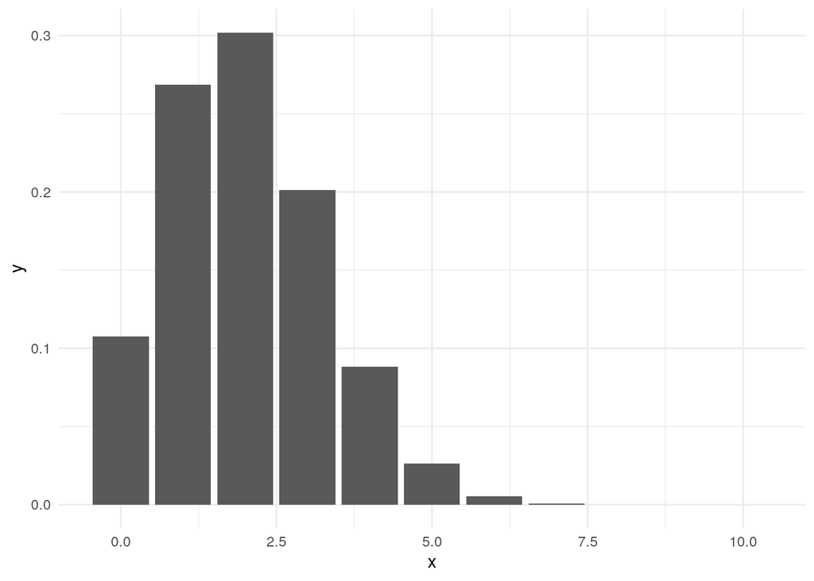

```r
library(ggplot2)
n = 10
p = 0.2
probs = dbinom(0:10, n, p)
df = data.frame(x = 0:10, y = probs)
p <- ggplot(data = df, aes(x = x, y = y)) + geom_bar(stat = "identity") +
    theme_minimal()
p
```

**Exercise:** Do the same, but with $p=0.5$. Which value for $p$ do you think will be best if you need to approximate the binomial with a normal distribution?

**Solution:** The approximation is best for $p=0.5$. Then the probability mass function is symmetric, as is the nomral probability density function. The approximation gets worse the closer $p$ is to $0$ or $1$.

## Normal distribution

For the continuous distributions – like the normal distributions – the probability density function gives the probability of observing a value between $a$ and $b$ when we integrate the pdf from $a$ to $b$: $P(a<X \le b)=\int_{a}^b f(x) dx$. Remember: $f(x)$ does not give the point probability of $x$ - the point probability is 0. Why?

We can plot the pdf for the normal distribution:

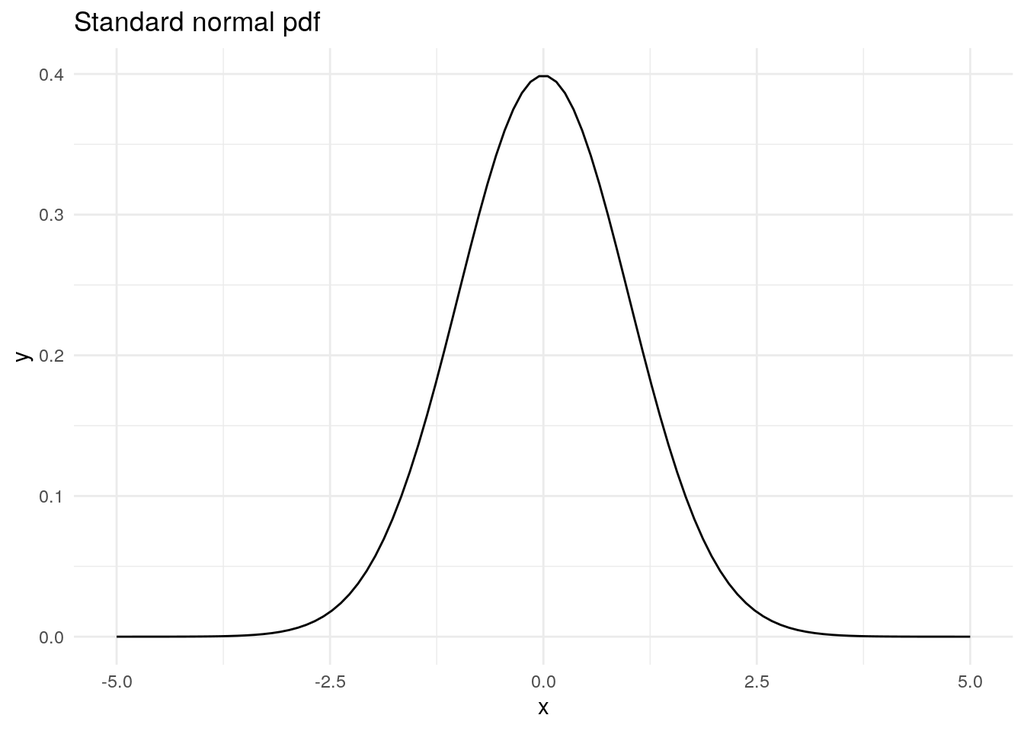

```r
x = seq(from = -5, to = 5, length = 100)
y = dnorm(x = x, mean = 0, sd = 1)
df = data.frame(x = x, y = y)
p = ggplot(data = df, aes(x = x, y = y)) + geom_line() + ggtitle("Standard normal pdf") +
    theme_minimal()
p
```

**Exercise:** Find $f(1.4)$ looking at the figure **and** using the `dnorm`. How can you interpret this value?

**Solution:** `dnorm(1.4)` gives `0.1497275`. For a small $\delta$, $P(1.4-\delta<Z<1.4+\delta) \approx 2\cdot0.15\cdot\delta$ for a standard normally distributed $Z$.

We can also plot the distribution using random generated values for the distribution. The function `rnorm()` draws random values from the given distribution. Below we draw `n=10000` values and make a histogram.

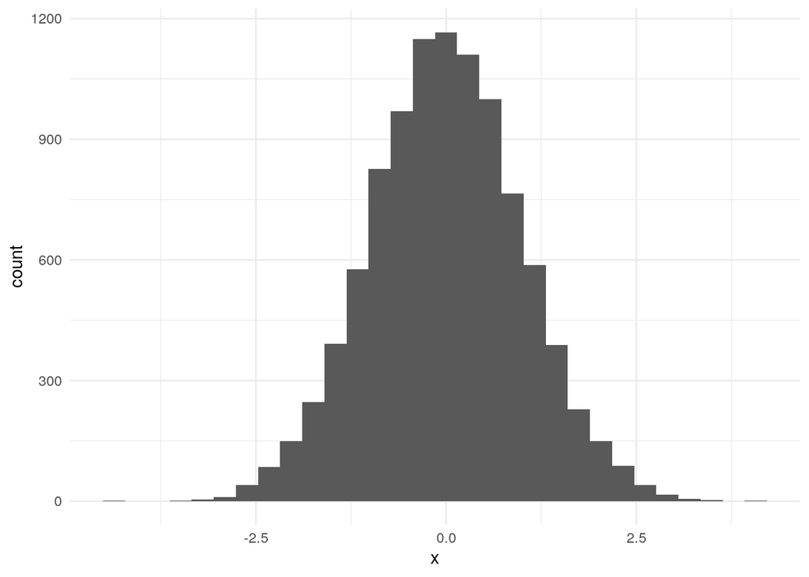

```r
n = 10000
x = rnorm(n = n, mean = 0, sd = 1)
p = ggplot(data.frame(x = x), aes(x)) + geom_histogram() + theme_minimal()
p
```

Try using smaller values of `n` and see what happends. Explain.

We can easily check the sample mean, variance and standard deviation of our drawn values by

```r
mean(x)
var(x)
sd(x)
```

**Exercise:** Check your drawn values to see that the mean and variance agree with what you specified. (No solution provided.)

## Chi-squared distribution

In our introductory course in statistics we learned that if $X$ is a standard normal variable then $X^2$ is chi-squared distributed with $1$ degree of freedom.

**Exercise:** What is the expected value and variance of a $\chi^2$-distribution with 1 degree of freedom? Look at the data drawn from the standard normal distribution above, and calulate the sample mean and variance of `x^2`. Does your result coincide with the known expected value and variance for this distribution? What happens to your result if you increase or decrease `n`?

**Solution:** A variable that has the chi-squared distribution with $\nu$ degrees of freedom has expected value $\nu$ and variance $2\nu$, so with $\nu=1$, the expected value is 1 and the variance 2. If $n$ is increased, sample mean and variance should get closer to 1 and 2, respectively (sample mean and variance are consistent estimators of distribution mean and variance).

We may also draw values directly from the chi-squared distribution.

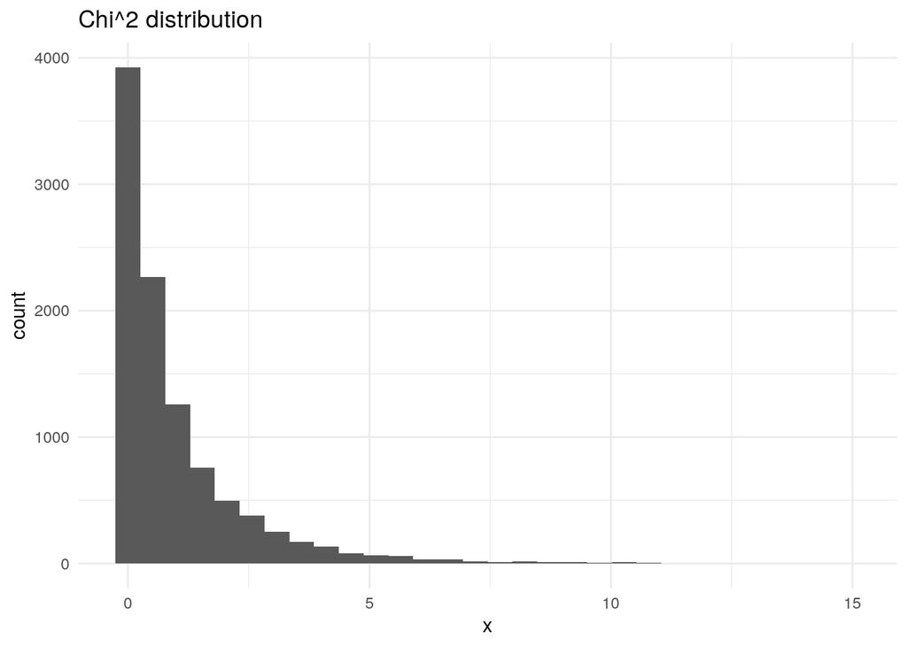

```r
n = 10000
x = rchisq(n = n, df = 1)
p = ggplot(data.frame(x = x), aes(x)) + geom_histogram() + ggtitle("Chi^2 distribution") +
    theme_minimal()
p
```

## t-distribution

Let $X_i$ be independent normal variables with mean $\mu$ and variance $\sigma^2$, and $\bar{X}=\frac{1}{n}\sum_{i=1}^n X_i$ and $S^2=\frac{1}{n-1}\sum_{i=1}^n (X_i-\bar{X})^2$. Further let
$$T=\frac{\bar{X}-\mu}{S/\sqrt{n}}$$

**Exercise:** What is the connection between $S^2$ and the chi-square distribution? What is the connection between $T$ and the $t$-distribution?

**Solution:** $(n-1)S^2/\sigma^2$ is chi-squared distributed with $n-1$ degrees of freedom. $T$ is $t$-distributed with $n-1$ degrees of freedom.

We can plot the pdf for the $t$-distribution with $n-1$ degrees of freedom, and add the standard normal for reference. Is the red curve the $t$ or normal curve? How can you see that?

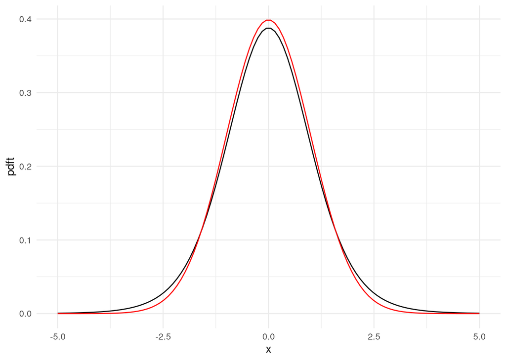

```r
library(ggplot2)
n = 10
x = seq(from = -5, to = 5, length = 100)
pdft = dt(x = x, df = n - 1)
pdfn = dnorm(x)
df = data.frame(x = x, pdft = pdft, pdfn = pdfn)
p = ggplot(data = df, aes(x = x)) + geom_line(aes(x = x, y = pdft)) +
    geom_line(aes(x = x, y = pdfn), colour = "red") + theme_minimal()
p
```

## The Fisher distribution

The final distribution is the Fisher distribution which is defined as a ratio between scaled chi-squared random variables. Let $V\sim \chi^2(v)$ and $W\sim \chi^2(w)$ then the ratio
$$\frac{V/v}{W/w}\sim F_{v,w}$$
follows a Fisher distribution with $v$ and $w$ degrees of freedom. We will use this distribution when working with ratios of variance estimates.

**Exercise:** Plot the pdf for the Fisher distribution with $v=5$ and $w=10$ degrees of freedom. Hint `df`.

**Solutions:** Do as in previous plots of pdfs. The R function for the pdf of an $F$-distribution is `df`. Be careful that you don’t name any `data.frame` `df`! See code and plot below.

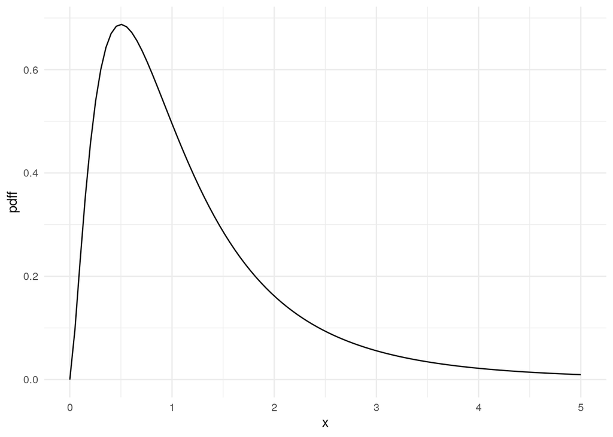

```r
library(ggplot2)
v = 5
w = 10
x = seq(from = 0, to = 5, length = 100)
pdff = df(x = x, df1 = v, df2 = w)
dframe = data.frame(x = x, pdff = pdff)
p = ggplot(data = dframe, aes(x = x, y = pdff)) + geom_line() + theme_minimal()
p
```

# Cumulative distribution function $F(x)$

The cumulative distribution function (cdf) is the probability that your observation is less or equal to x,
$$F(x) = P(X\leq x) =
\begin{cases} \int_{-\infty}^{x} f_x(t)dt \quad \text{for continuous distributions}\\
\sum_{t\leq x} f(t) \quad \text{for discrete distributions}
\end{cases}$$

The following plot shows the cdf of a standard normal distribution.

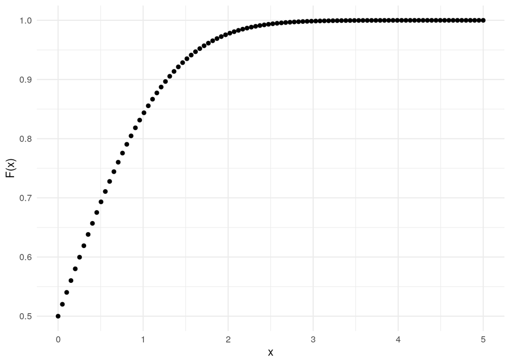

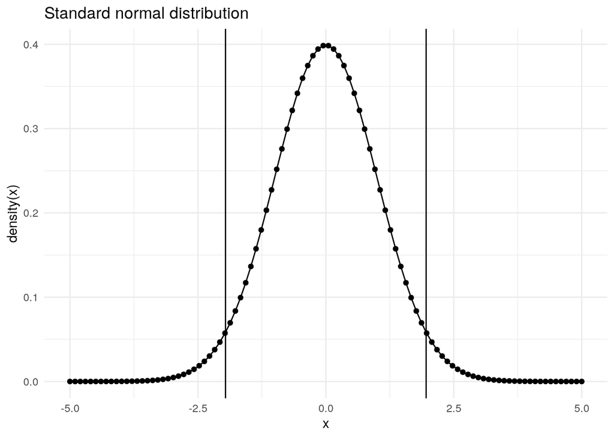

```r
x = seq(from = -5, to = 5, length = 100)
y = dnorm(x = x, mean = 0, sd = 1)
z = 1.96
qplot(x, y, geom = c("point", "line"), main = "Standard normal distribution",
    xlab = "x", ylab = "density(x)") + geom_vline(xintercept = c(-z,
    z)) + theme_minimal()
```

```r
alpha_lower = pnorm(q = -z, mean = 0, sd = 1, lower.tail = TRUE)
alpha_upper = 1 - pnorm(q = z, mean = 0, sd = 1, lower.tail = TRUE)
c(alpha_lower, alpha_upper)
```

```
## [1] 0.0249979 0.0249979
```

Note that for the upper tail, we could have written `alpha_upper = pnorm(q = q, mean = 0, sd = 1, lower.tail = FALSE)`. The logical option `lower.tail` indicate if you want to calculate the upper, $P(X>x)$, or the lower, $P(X\leq x)$, tail. The default is `TRUE`, meaning that if you don’t include this option as input it will automatically calculate the lower tail.

**Exercise** Find the cdf of $x=-5$ and $x=5$ from looking at the figure **and** using the distribution function in R.

**Solutions:** `pnorm(-5)` and `pnorm(5)` give `2.866516e-07` and `0.9999997`, respectively, i.e. close to 0 and 1. This agrees with the figure of the cdf.

Let’s check that the critical values $z_{\alpha/2}$ and $z_{1-\alpha/2}$ are -1.96 and 1.96 when $\alpha = 0.05$. For this, we use the quantile function (inverse cdf).

```r
z_l = qnorm(0.025, mean = 0, sd = 1)
z_u = qnorm(0.975, mean = 0, sd = 1)
c(z_l, z_u)
```

```
## [1] -1.959964  1.959964
```

**Solution:** We can use the following code:

```r
pt(q = 1.8, df = 1)
```

```
## [1] 0.8385855
```

```r
pt(q = 2, df = 1) - pt(q = 1, df = 1)
```

```
## [1] 0.1024164
```

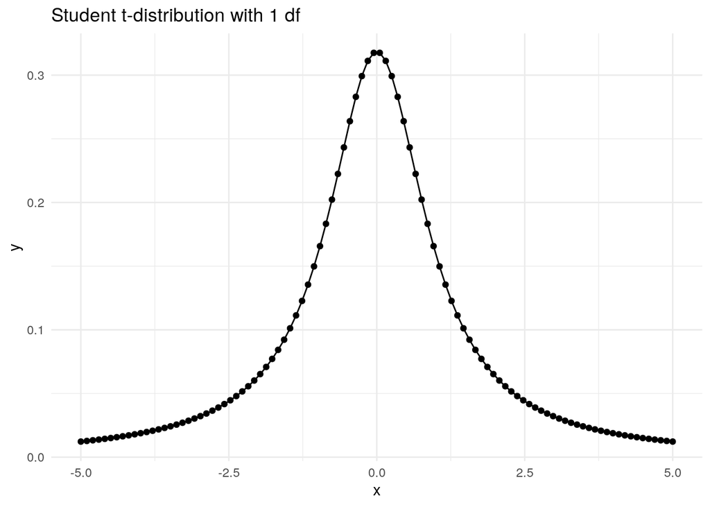

# Writing a simple Z-test as a function

Let us assume that $X$ is a random variable from a normal distribution with know variance $\sigma^2$ and we want to perform a hypothesis test to test that the mean of $X$ is not equal to $0$, $\mu\neq 0$, that is, a two-sided test.

Assume that have collected a random sample $(X_1,X_2,\ldots,X_n)$, and that we may assume that $\frac{\bar{X}-\mu}{\sigma/\sqrt{n}}$ follows a standard normal distribution (and $\sigma^2$ is known). Here $\bar{X}=\frac{1}{n} \sum_{i=1}^n X_i$. A t-test is implemented in R (function `t.test`) but no `z.test`, so now we (for the sake of exercise) want to implement our own z-test.

Then we need a function with the data and given (known) standard deviation as input. We assume that the data are given in a vector named `x`.

Read and discuss what is done here.

```r
myz.test <- function(x, sd) {
    n <- length(x)
    xbar <- mean(x)
    zobs <- xbar/(sd/sqrt(n))
    # if you what to print remove hashtag in next line
    # print(paste('Zobs',zobs))
    pval <- 2 * pnorm(abs(zobs), lower.tail = FALSE)
    # if you what to print remove hashtag in next line
    # print(paste('P-value',pval))
    return(list(statistic = zobs, p.value = pval))
}
```

To use the function we first generate some data and then call the function.

```r
testds <- rnorm(100, mean = 0.5, sd = 6)
myz.test(testds, sd = 6)
```

```
## $statistic
## [1] 1.414453
##
## $p.value
## [1] 0.1572291
```

If you want to run this function for many simulated data sets and put the results from `myz.test` into a matrix you may use the following simple for-loop:

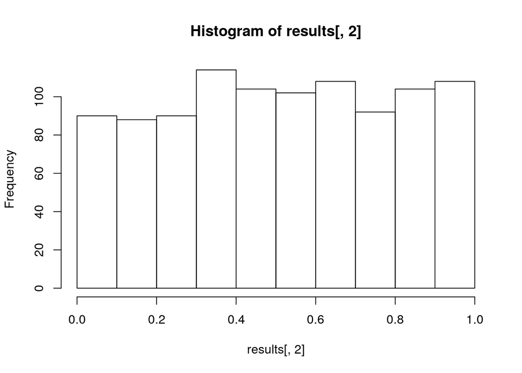

```r
mu = 0
sigma = 4
n = 10  # size of each data set
B = 1000  # number of data sets to simulate
results <- matrix(NA, ncol = 2, nrow = B)
for (i in 1:B) {
    testX <- rnorm(n, mean = mu, sd = sigma)
    thisresult <- myz.test(testX, sigma)
    results[i, ] <- c(thisresult$statistic, thisresult$p.value)
}
hist(results[, 2])
```

**Exercise:** Run the code on your computer. What is done here? What does the histogram display? Hint: what is the distribution of $p$-values from true null hypotheses?

**Solution:** The test $H_0\colon\mu=0$ versus $H_1\colon\mu\neq0$ is performed 1000 times. The histogram (above) displays the $p$-values. They seem uniformly distributed, as $p$-values from a true simple nullhypothis should be with continuous data.

If you want reproducible results, it is useful to set the random generator seed. That is done as `set.seed(a)` where `a` is the seed you want to set.

# Plotting pdfs

For the user who wants to do advanced graphics: Below is an example of how to draw multiple plots using `ggplot`.

**Exercise:** What is this plot showing?

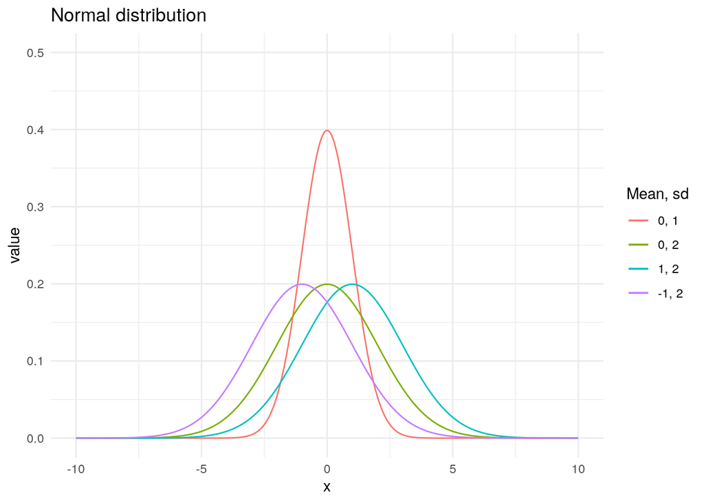

```r
x = seq(from = -10, to = 10, length = 500)
y1 = dnorm(x, mean = 0, sd = 1)
y2 = dnorm(x, mean = 0, sd = 2)
y3 = dnorm(x, mean = 1, sd = 2)
y4 = dnorm(x, mean = -1, sd = 2)
df = data.frame(x, y1, y2, y3, y4)
ggplot(df, aes(x, y = value, color = variable)) + geom_line(aes(y = y1,
    col = "y1")) + geom_line(aes(y = y2, col = "y2")) + geom_line(aes(y = y3,
    col = "y3")) + geom_line(aes(y = y4, col = "y4")) + ylim(0, 0.5) +
    ggtitle("Normal distribution") + scale_colour_discrete(name = "Mean, sd",
    breaks = c("y1", "y2", "y3", "y4"), labels = c("0, 1", "0, 2", "1, 2 ",
        "-1, 2")) + theme_minimal()
```

Let’s assume we flip a coin where the probability of getting head is $p = P(head) = P(X=1) = 0.5$, and the probabiltiy of getting tails is $1-p = P(tails) = P(X=0)$. The following shows the number of times we get head and tails of a throw when we try 1000 times

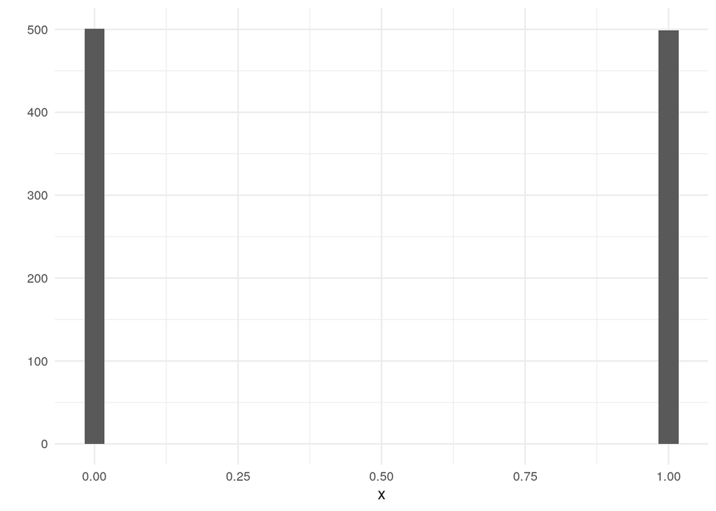

```r
n = 1000
p = 0.5
x = rbinom(n, size = 1, prob = p)
qplot(x, geom = "histogram") + theme_minimal()
```

Note here that the option `size` refers the number of trials.

**Exercise:** Increase the number of trials to 100 when holding the other parameters constant. Can you explain what happens here and why? What is the mean and variance of this distribution? What is the probability of having only one head when you do 100 trials?

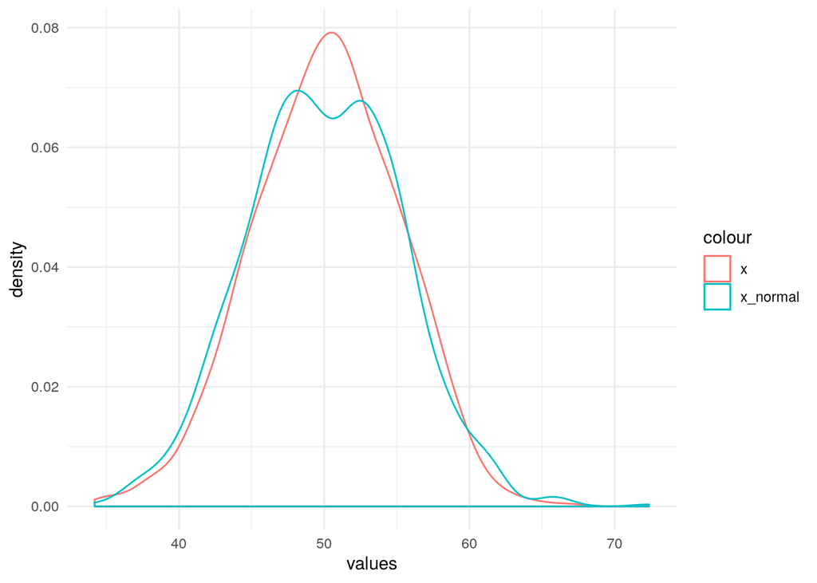

```r
n = 1000
p = 0.5
x = rbinom(n, size = 100, prob = 0.5)
x_normal = rnorm(n, mean = 100 * p, sd = sqrt(100 * p * (1 - p)))
# hist(x) hist(x_normal)

df = data.frame(x = x, x_normal = x_normal)
ggplot(data = df, aes(x = values), color = variable) + geom_density(aes(x = x,
    col = "x")) + geom_density(aes(x = x_normal, col = "x_normal")) +
    theme_minimal()
```

**Exercise:** Make one plot of the pdf and one plot of the cdf for each of the following distributions

1. $\chi^2$- distributions with 1, 2, 3, 4, 6 and 9 degrees of freedom
2. Student t-distribution with 1, 2, 3, 4 and 5 degrees of freedom.

**Solution:** R code and plots:

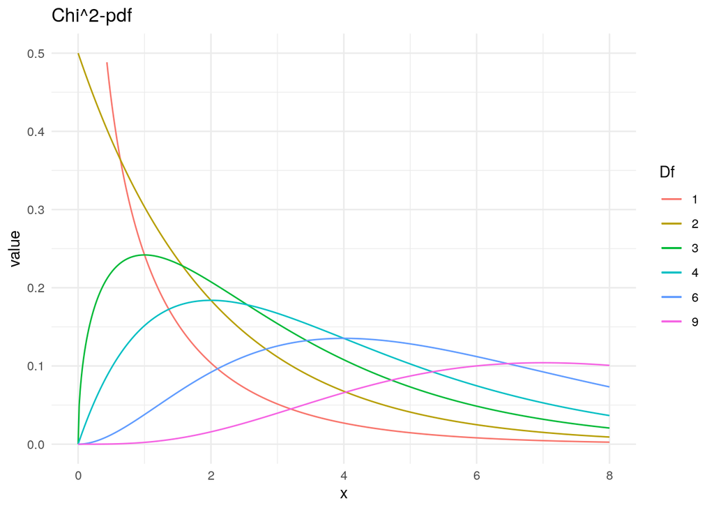

```r
x = seq(from = 0, to = 8, length = 500)
y1 = dchisq(x, df = 1)
y2 = dchisq(x, df = 2)
y3 = dchisq(x, df = 3)
y4 = dchisq(x, df = 4)
y6 = dchisq(x, df = 6)
y9 = dchisq(x, df = 9)

df = data.frame(x, y1, y2, y3, y4, y6, y9)
ggplot(df, aes(x, y = value, color = variable)) + geom_line(aes(y = y1,
    col = "y1")) + geom_line(aes(y = y2, col = "y2")) + geom_line(aes(y = y3,
    col = "y3")) + geom_line(aes(y = y4, col = "y4")) + geom_line(aes(y = y6,
    col = "y6")) + geom_line(aes(y = y9, col = "y9")) + ylim(0, 0.5) +
    theme_minimal() + ggtitle("Chi^2-pdf") + scale_colour_discrete(name = "Df",
    breaks = c("y1", "y2", "y3", "y4", "y6", "y9"), labels = c("1", "2",
        "3", "4", "6", "9"))
```

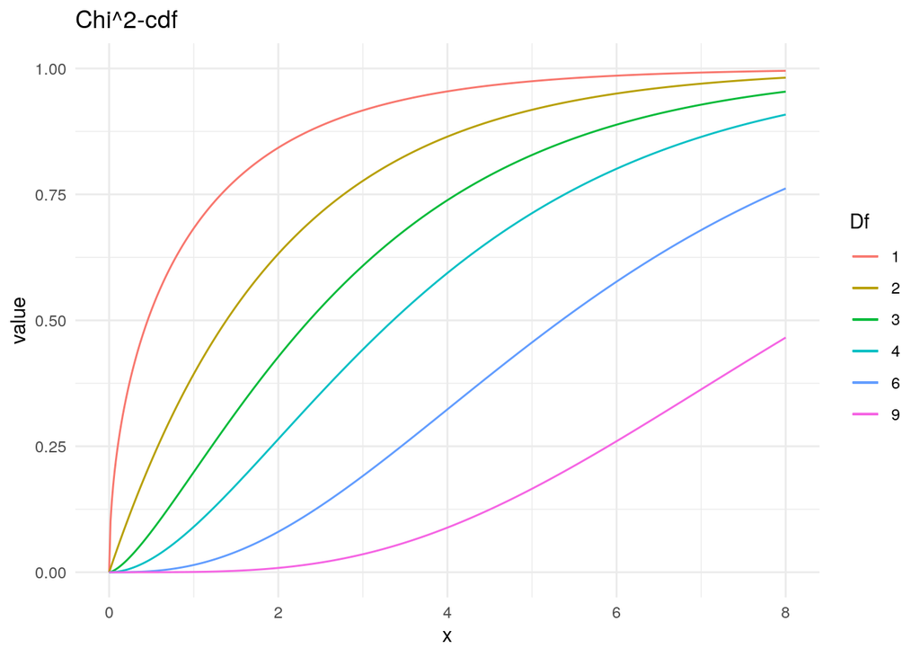

```r
x = seq(from = 0, to = 8, length = 500)
y1 = pchisq(x, df = 1)
y2 = pchisq(x, df = 2)
y3 = pchisq(x, df = 3)
y4 = pchisq(x, df = 4)
y6 = pchisq(x, df = 6)
y9 = pchisq(x, df = 9)

df = data.frame(x, y1, y2, y3, y4, y6, y9)
ggplot(df, aes(x, y = value, color = variable)) + geom_line(aes(y = y1,
    col = "y1")) + geom_line(aes(y = y2, col = "y2")) + geom_line(aes(y = y3,
    col = "y3")) + geom_line(aes(y = y4, col = "y4")) + geom_line(aes(y = y6,
    col = "y6")) + geom_line(aes(y = y9, col = "y9")) + ylim(0, 1) +
    ggtitle("Chi^2-cdf") + theme_minimal() + scale_colour_discrete(name = "Df",
    breaks = c("y1", "y2", "y3", "y4", "y6", "y9"), labels = c("1", "2",
        "3", "4", "6", "9"))
```

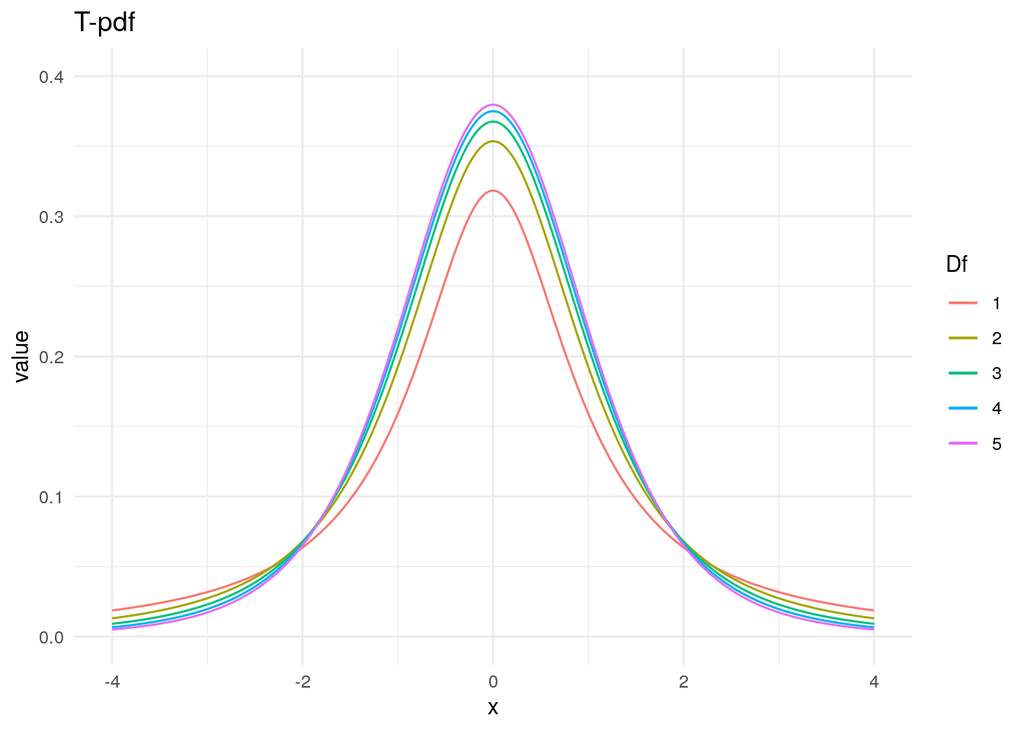

```r
x = seq(from = -4, to = 4, length = 500)
y1 = dt(x, df = 1)
y2 = dt(x, df = 2)
y3 = dt(x, df = 3)
y4 = dt(x, df = 4)
y5 = dt(x, df = 5)

df = data.frame(x, y1, y2, y3, y4, y5)
ggplot(df, aes(x, y = value, color = variable)) + geom_line(aes(y = y1,
    col = "y1")) + geom_line(aes(y = y2, col = "y2")) + geom_line(aes(y = y3,
    col = "y3")) + geom_line(aes(y = y4, col = "y4")) + geom_line(aes(y = y5,
    col = "y5")) + ylim(0, 0.4) + ggtitle("T-pdf") + scale_colour_discrete(name = "Df",
    breaks = c("y1", "y2", "y3", "y4", "y5"), labels = c("1", "2", "3",
        "4", "5")) + theme_minimal()
```

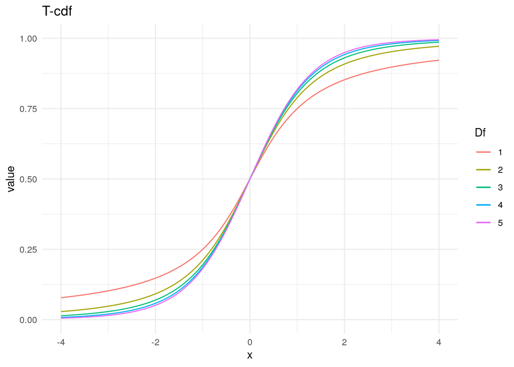

```r
x = seq(from = -4, to = 4, length = 500)
y1 = pt(x, df = 1)
y2 = pt(x, df = 2)
y3 = pt(x, df = 3)
y4 = pt(x, df = 4)
y6 = pt(x, df = 5)

df = data.frame(x, y1, y2, y3, y4, y5)
ggplot(df, aes(x, y = value, color = variable)) + geom_line(aes(y = y1,
    col = "y1")) + geom_line(aes(y = y2, col = "y2")) + geom_line(aes(y = y3,
    col = "y3")) + geom_line(aes(y = y4, col = "y4")) + geom_line(aes(y = y6,
    col = "y5")) + ylim(0, 1) + ggtitle("T-cdf") + scale_colour_discrete(name = "Df",
    breaks = c("y1", "y2", "y3", "y4", "y5"), labels = c("1", "2", "3",
        "4", "5")) + theme_minimal()
```

Here is more about using `ggplot` to plot functions in general: http://t-redactyl.io/blog/2016/03/creating-plots-in-r-using-ggplot2-part-9-function-plots.html